# HAR machine learning project

A.Bailey

Friday, August 21st, 2015

# Executive summary

# Introduction

The goal of this project was to use machine learning to predict the manner of a dumbbell curl exercise performed in a test data set using a training set using data from the [Human Activity Recognition Weight Lifting Exercises Dataset](http://groupware.les.inf.puc-rio.br/har) (Velloso et al. 2013).

In the report by (Velloso et al. 2013) they describe collecting data using sensors as positioned in Figure 1 such that:

*“Participants were asked to perform one set of 10 repetitions of the Unilateral Dumbbell Biceps Curl in five different fashions: exactly according to the specification (Class A), throwing the elbows to the front (Class B), lifting the dumbbell only halfway (Class C), lowering the dumbbell only halfway (Class D) and throwing the hips to the front (Class E). Class A corresponds to the specified execution of the exercise, while the other 4 classes correspond to common mistakes.”*

[figure not shown]

**Figure 1:** Sensing set-up figure reproduced from (Velloso et al. 2013)

This yielded sensor observations with a large set of features from which they used 17 to predict the manner in which the dumbbell exercise was performed, the `classe` feature.

Here I use a training set containing the same set of features in (Velloso et al. 2013) to build a model using machine learning methods in `R` to predict the `classe` of dumbbell exercise preformed in a test set of sensor observations.

# Obtaining, loading and tidying the data

The following code will download the training and test data, and create a log file.

```r
# Download URL for training data
trainUrl <- "http://d396qusza40orc.cloudfront.net/predmachlearn/pml-training.csv"

testUrl <- "http://d396qusza40orc.cloudfront.net/predmachlearn/pml-testing.csv"

# Download training data if not already downloaded
if(!file.exists("pml-training.csv")){
        download.file(trainUrl,destfile="pml-training.csv")
        dateDownloaded <- date()
        # Create logfile
        log_con <- file("pml-training_download.log")
        cat (trainUrl,"\n","destfile= pml-training.csv",
             "\n","destdir =", getwd(),"\n",dateDownloaded,
             file = log_con)
        close(log_con)
}

# Download test data if not already downloaded
if(!file.exists("pml-testing.csv")){
        download.file(testUrl,destfile="pml-testing.csv")
        dateDownloaded <- date()
        # Create logfile
        log_con <- file("pml-testing_download.log")
        cat (testUrl,"\n","destfile= pml-testing.csv",
             "\n","destdir =", getwd(),"\n",dateDownloaded,
             file = log_con)
        close(log_con)
}
```

Having had a look at the downloaded files I can see that the NA strings need to be set for `NA, #DIV0` and empty cells when the data is read into `R`:

```r
# Load training and test data
pml.training <- read.csv("pml-training.csv",header = TRUE,
                         na.strings = c('NA','#DIV/0!',''))
pml.testing <- read.csv("pml-testing.csv",header = TRUE,
                        na.strings = c('NA','#DIV/0!',''))
```

As an initial feature selection step, I chose a simple strategy to tidy the data of just removing all columns with `NAs` to begin with from both the training and test date. As this resulted in a good model, I didn’t have cause to revise this strategy.

Having removed the `NAs`, I also removed the metadata columns 1 to 7 from both datasets. Inspection of the training data indicated that the `classe` variable that we wish to predict for the test set is in the final column of the training set. This indicates the manner of the dumbbell exercise as described in the introduction.

Also from inspection, I removed the 7 metadata columns as these aren’t predictive variables.

These steps were applied to both training and test data.

```r
# Remove all NAs
train.tdy <- pml.training[sapply(pml.training, function(x) !any(is.na(x)))]
test.tdy <-  pml.testing[sapply(pml.testing, function(x) !any(is.na(x)))]

# Remove metadata from training and test set
train.tdy <- train.tdy[,-c(1:7)]
test.tdy <-  test.tdy[,-c(1:7)]
```

# Splitting the data and further preprocessing

The rest of the report uses the Caret package to build, train, tune and evaluate the model (2015; Kuhn 2008).

I split the training data into model training and model cross validation sets, 60% for training and 40% for cross validation.

Having checked that there were no near zero variance variables remaining, I filtered the remaining variables by identifying and removing any that are highly correlated (>0.9).

These steps were applied to the training, cross validation and test sets:

```r
# Split data for cross validation and training, 60% training set,
# 40% cross validation set
inTrain <- createDataPartition(train.tdy$classe, p = 0.6, list=FALSE)
# train to tune models, cv to evaluate model performance
train <- train.tdy[inTrain,]
cv  <- train.tdy[-inTrain,]

# Find highly correlated variables in training set
descrCorr <- cor(train[,-53], use="complete")
highCorr <- findCorrelation(descrCorr, 0.9)

# Remove highly correlated variables from training, cv and test data
train.c <- train[, -highCorr]
cv.c <- cv[, -highCorr]
test.c <- test.tdy[,-highCorr]
```

This left 46 features to use to build the models.

# Exploring the training set

From building the models, it became clear that an accurate model could be built without more in-depth feature selection. However to illustrate how I would look in more detail to refine the selection of variables Figure 2 shows a pairs plot for 5 *“interesting”* looking features. For example, there is some separation by `classe` for `yaw_belt` plotted against `pitch_forearm`.

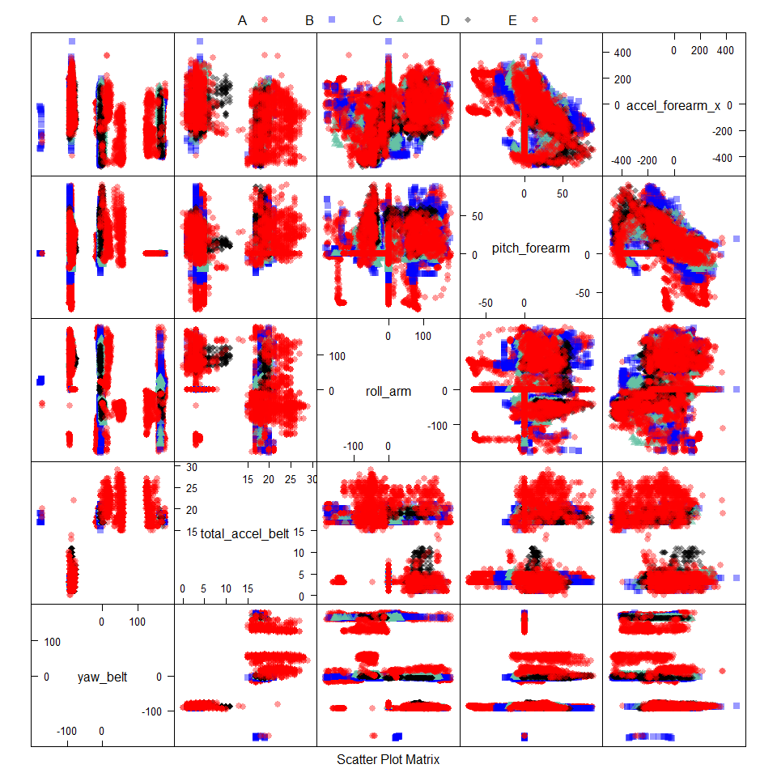

**Figure 2:** Pairs plot of five features in training set

```r
# Create pairs plot of five selected variables
plot.1 <- featurePlot(x=train.c[,c(2,3,10,34,40)], y = train.c$classe,
                      plot="pairs",
                      ## Add a key at the top
                      auto.key = list(columns = 5))
plot.1
```

# Creating and tuning three models

```r
# Set training control for 5 fold cross validation with two repeats
cvCtl <- trainControl(method = "cv", number = 5, repeats = 2)
```

I chose to build three types of model: a Classification and regression tree (CART) model, a Quadratic Discriminant Analysis (QDA) model and a Random Forest model. These were chosen to compare their speed and accuracy following the examples detailed in (Kuhn 2008). The strategy being to find the balance between speed and performance. I set the seed for each train call so that the models can be compared later.

```r
# CART model, set tuneLength to evaluate broader set of models that defualt of 3
set.seed(1972)
rpartTune <- train(classe~., data=train.c, method = "rpart", tuneLength = 30,
                  trControl =cvCtl)
# Quadratic discriminant model
set.seed(1972)
qdaTune <- train(classe~., data=train.c, method = "qda", tuneLength = 30,
                trControl =cvCtl)
# Random forest model
set.seed(1972)
rfTune <- train(classe~., data=train.c, method = "rf",
                 trControl =cvCtl)
```

# Evaluating the models with the cross validation set

To evaluate the models performance I used the 40% of the training set put aside to predict the `classe` variables. The confusion matrices indicate how well the models did with these predictions:

```r
# Cross validate CART model using cv portion of training
train.rp <- predict(rpartTune, newdata = cv.c, type= "raw")
confus.rp <- confusionMatrix(cv$classe,train.rp,dnn = c("CV", "Training"))

# Cross validate QDA model using cv portion of training
train.q <- predict(qdaTune, newdata = cv.c,type="raw")
confus.q <- confusionMatrix(cv$classe,train.q,dnn = c("CV", "Training"))

# Cross validate random forest model using cv portion of training
train.rf <- predict(rfTune, newdata = cv.c, type= "raw")
confus.rf <- confusionMatrix(cv$classe,train.rf,dnn = c("CV", "Training"))

# Confusion matrix for CART model
confus.rp$table
```

```
##    Training
## CV     A    B    C    D    E
##   A 2047   82   60   14   29
##   B  168 1130  119   85   16
##   C   23  131 1142   34   38
##   D   56   75  127 1012   16
##   E   48  102  106   63 1123
```

```r
# Confusion matrix for QDA model
confus.q$table
```

```
##    Training
## CV     A    B    C    D    E
##   A 2021   97   79   31    4
##   B   96 1242  156    5   19
##   C    1   76 1269   10   12
##   D    3    1  182 1079   21
##   E    0   24   58   42 1318
```

```r
# Confusion matrix for random forest model
confus.rf$table
```

```
##    Training
## CV     A    B    C    D    E
##   A 2230    1    1    0    0
##   B   12 1501    5    0    0
##   C    0    7 1354    7    0
##   D    0    1   10 1274    1
##   E    0    0    1    2 1439
```

Confirming what is shown in the confusion Figure 3 indicates that the Random Forest is the best performing model with 99% accuracy, quantified along with the out of sample error in Table 1.

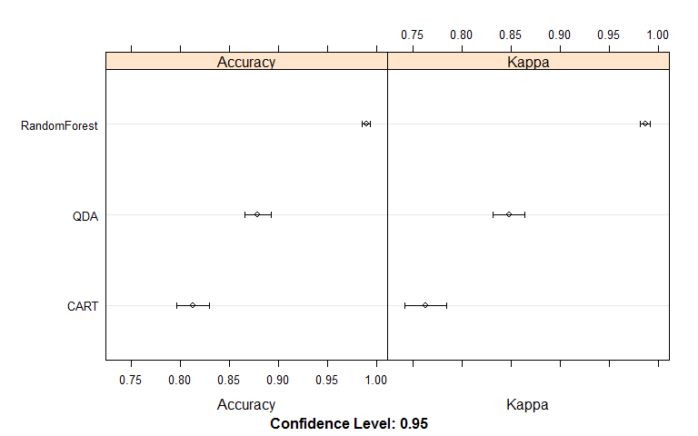

**Figure 3:** Dot plot of model performance

```r
# Compare model performance using resampling results, seed set same at train
cvValues <- resamples(list(CART = rpartTune, QDA = qdaTune,
                           RandomForest=rfTune))

# Plot comparison of model performance
dotplot(cvValues)
```

```r
# Calculate accuracy and out of sample error
err.rp <- c(confus.rp$overall[1], 1 -confus.rp$overall[1])
err.q <- c(confus.q$overall[1],1 -confus.q$overall[1])
err.rf <- c(confus.rf$overall[1],1 -confus.rf$overall[1])

# Create a table of accuracy and out of sample error
err.table <- round(rbind(err.rp,err.q,err.rf),2)
rownames(err.table) <- c("CART","QDA","Random Forest")
colnames(err.table) <- c("Accuracy","Out of sample error")
kable(err.table)
```

|  | Accuracy | Out of sample error |
| --- | --- | --- |
| CART | 0.82 | 0.18 |
| QDA | 0.88 | 0.12 |
| Random Forest | 0.99 | 0.01 |

**Table 1:** Model accuracy and out of sample error

As a check on feature selection, Table 2 shows the top 10 most important variables in the Random Forest Model.

```r
# Find feature importance for random forest model
vi <- varImp(rfTune)$importance
o <- order(vi$Overall, decreasing = TRUE)
vio <- vi[o,,drop = FALSE]
kable(round(head(vio,10),2))
```

|  | Overall |
| --- | --- |
| yaw_belt | 100.00 |
| pitch_forearm | 80.63 |
| magnet_dumbbell_z | 68.22 |
| pitch_belt | 65.49 |
| magnet_dumbbell_y | 51.48 |
| roll_forearm | 44.29 |
| magnet_belt_y | 41.50 |
| magnet_belt_z | 28.81 |
| gyros_belt_z | 28.38 |
| magnet_dumbbell_x | 26.70 |

**Table 2:** Top 10 most important features in the Random Forest Model

# Predicting the test set

This is the code to produce the project submission files:

```r
test.pred <- predict(rfTune, newdata = test.c, type= "raw")

# write output
pml_write_files = function(x){
                 n = length(x)
                 for(i in 1:n){
                         filename = paste0("problem_id_",i,".txt")
                         write.table(x[i],file=filename,quote=FALSE,
                                     row.names=FALSE,col.names=FALSE)
                 }
         }

pml_write_files(test.pred)
```

The predictions for the `classe` of the 20 test set dumbbell exercises are: B, A, B, A, A, E, D, B, A, A, B, C, B, A, E, E, A, B, B, B

# Conclusions

The Random Forest model performed best, it was 99% accurate with a 0.01 out of sample error in predicting the cross validation set, but was the slowest to run. I therefore used the Random Forest model to predict the manner of the dumbbell exercise in the test set. However, more careful selection of the features could be used to attempt to train a model that is of similar accuracy, but is faster.

# Session information

Here is the session information about the packages I used, their versions, and the version of R that I used for this assignment:

[session information not shown]

References

James, Gareth, Daniela Witten, Trevor Hastie, and Robert Tibshirani. 2013. *An Introduction to Statistical Learning*. Springer.

Kuhn, Max. 2008. “Building Predictive Models in R Using the Caret Package.” *Journal of Statistical Software* 28 (5). American Statistical Association: 1–26.

Velloso, Eduardo, Andreas Bulling, Hans Gellersen, Wallace Ugulino, and Hugo Fuks. 2013. “Qualitative Activity Recognition of Weight Lifting Exercises.” In *Proceedings of the 4th Augmented Human International Conference*, 116–23. AH ’13. New York, NY, USA: ACM. doi:10.1145/2459236.2459256.

2015. https://cran.r-project.org/web/packages/caret/index.html.